# Fourth Week: Hypothesis Testing

TIMSS Analysis

student name

2018-03-09 01:30:29

```r
library(dplyr)
```

```r
library(ggplot2)
library(highcharter)
library(knitr)
library(readr)

setwd("/media/saleh/New Volume/study/uni/8/data science/HW/HW4/hw_04")
```

**LOAD DATA**

```r
bcg = read_rds("Data/data/bcg.rds") # school background
bsg = read_rds("Data/data/bsg.rds") # student background
btg = read_rds("Data/data/btm.rds") # Teacher background
bsa = read_rds("Data/data/bsa.rds") # strudent result
bst = read_rds("Data/data/bst.rds") # student-teacher linkage
bsr = read_rds("Data/data/bsr.rds") # within-country
bts = read_rds("Data/data/bts.rds")
```


# تمرین سری چهارم: چقدر ریاضی بلدیم و چرا؟

لطفا مقاله زیر را مطالعه بفرمایید.

[چرایی رتبه ضعیف ایران در آزمون تیمز](https://goo.gl/gX8DZc)

> با استفاده از داده های ارزیابی تیمز ۲۰۱۵ ادعاهای زیر را مورد ارزیابی قراردهید. برای هر سوال علاوه بر استدلال آماری که در غالب آزمون فرض تعریف می شود از تصویرسازی مناسب باهر دو ابزار ggplot2 و highcharter استفاده نمایید. به دلخواه به هفت گزاره از موارد زیر پاسخ دهید.

۱. میران رضایت معلمان در پیشرفت تحصیلی دانش آموزان موثر است.

۲. والدینی که تحصیلات بیشتری دارند دارای فرزندان موفق تری می باشند.

question Used : BSBG07B : father BSBG07A : mother

i remove rows that its education for father and mother is 8 correspond to no data that they have :)

```r
bsg %>%
   mutate (math_score = (bsmmat01+ bsmmat02+ bsmmat03 +  bsmmat04 +  bsmmat05)/5,
          sci_score = (bsssci01+ bsssci02+ bsssci03 +  bsssci04 +  bsssci05)/5) %>%
  select(idcntry,idstud,mo_ed = bsbg07a, fa_ed = bsbg07b , math_score , sci_score)-> par_edu_mathsco
```

as father and mother education are not independent I use two test separtely for each of them. i just use math score for checking the diffrence . **father importance**

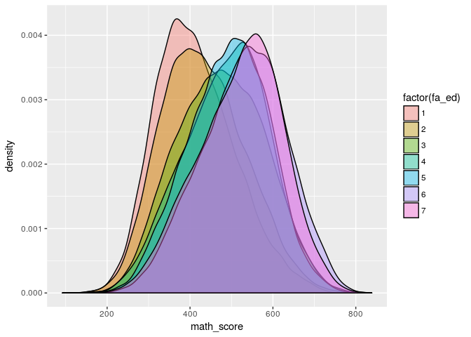

```r
par_edu_mathsco %>%
  filter(fa_ed!=8) -> father_imp
father_imp  %>%
  na.omit(.,cols = c('math_score', 'fa_ed')) %>%
  ggplot(aes(x =math_score  , fill = factor(fa_ed))) + geom_density(alpha = 0.4)
```

as you can see the mean of math score for each group is some how sorted by its father education level . it seams that normal assumption is good so i use one way anova to to test if they groups are diffrent .

```r
father_imp %>% aov(math_score ~ factor(fa_ed) , data = .) -> fit
summary.aov(fit)
```

```
##                   Df    Sum Sq  Mean Sq F value Pr(>F)
## factor(fa_ed)      6 2.556e+08 42607453    4139 <2e-16 ***
## Residuals     185535 1.910e+09    10295
## ---
## Signif. codes:  0 '***' 0.001 '**' 0.01 '*' 0.05 '.' 0.1 ' ' 1
```

as pr(>F) comes low enough i reject the null hypoththis that theire mean are the same in levels of education .

**Mother importance on math**

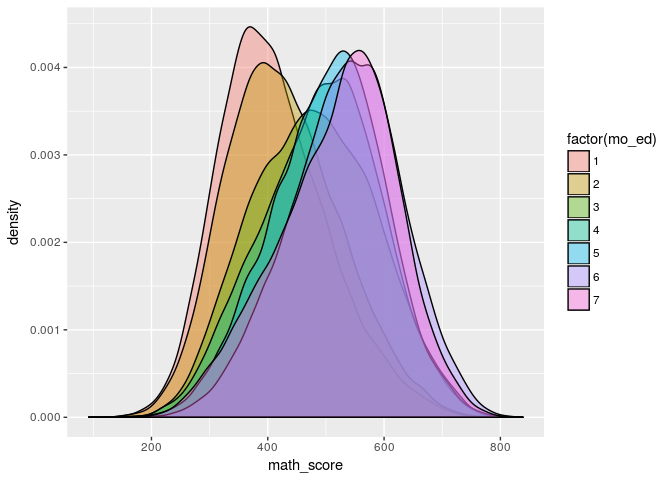

```r
par_edu_mathsco %>%
  filter(mo_ed!=8) -> mother_imp
mother_imp  %>%
  na.omit(.,cols = c('math_score', 'mo_ed')) %>%
  ggplot(aes(x =math_score  , fill = factor(mo_ed))) + geom_density(alpha = 0.4)
```

```r
mother_imp %>% aov(math_score ~ factor(mo_ed) , data = .) -> fit
summary.aov(fit)
```

```
##                   Df    Sum Sq  Mean Sq F value Pr(>F)
## factor(mo_ed)      6 3.337e+08 55622814    5611 <2e-16 ***
## Residuals     195792 1.941e+09     9912
## ---
## Signif. codes:  0 '***' 0.001 '**' 0.01 '*' 0.05 '.' 0.1 ' ' 1
```

so like father , mother has effect on math score of students.

۳. امکانات رفاهی در خانه موجب پیشرفت تحصیلی می گردد.

in here i use question six to generate a creterion for having walfair in home . i count how many option do student have in this question .

```r
bsg %>%
   mutate (math_score = (bsmmat01+ bsmmat02+ bsmmat03 +  bsmmat04 +  bsmmat05)/5,
          welfair = (14-(bsbg06a+bsbg06b+bsbg06c+bsbg06d+bsbg06e+bsbg06f+bsbg06g)))%>%
  select(idcntry,idstud, welfair  , math_score) -> well_score
```

max well fair is 7 i remove other rows for question 6 because we dont know what they think as wellfair:) like before i use one way anova.

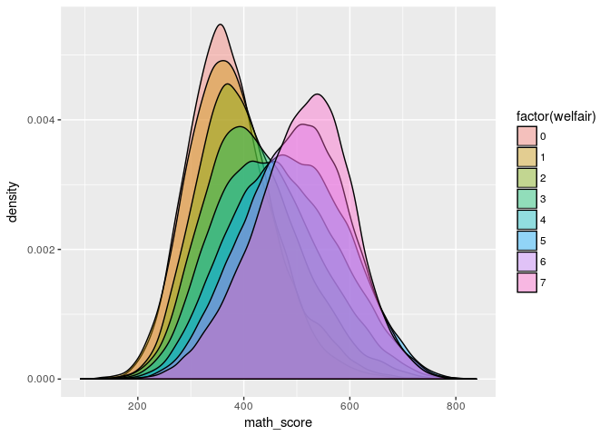

```r
well_score %>%
  na.omit(.,cols = c('math_score', 'welfair')) %>%
  ggplot(aes(x = math_score , fill = factor(welfair))) + geom_density(alpha=0.4)
```

as it can be seen on plot more wellfaire give youve got more math score :) by anova test :

```r
well_score %>%
  aov(math_score ~ factor(welfair) , data = .) -> fit
summary.aov(fit)
```

```
##                     Df    Sum Sq  Mean Sq F value Pr(>F)
## factor(welfair)      7 2.973e+08 42474824    4303 <2e-16 ***
## Residuals       262553 2.592e+09     9871
## ---
## Signif. codes:  0 '***' 0.001 '**' 0.01 '*' 0.05 '.' 0.1 ' ' 1
## 17569 observations deleted due to missingness
```

by test too it verified.

۴. محیط آرام مدرسه نقش مهمی در پیشرفت تحصیلی دارد.

for this part i just use information in question 15 and 16 of student they talk about their feeling on school. i group calm criterion in 5 category.

```r
bsg %>%
  select(idcntry,idschool,idstud,idclass, bsmmat01:bsmmat05 , bsbg15a:bsbg16i)%>%
  na.omit() %>%
  group_by(idcntry,idstud,idschool,idclass) %>%
  summarize(math_score = mean(c(bsmmat01:bsmmat05)),
            calm = round(mean(c(4-(bsbg15a:bsbg15g),(bsbg16a:bsbg16i)))))->
  calmness
```

ploting the diffrence in 5 group of clamness that by increasing it we have more clam .

```r
hcboxplot(x = calmness$math_score, var = calmness$calm,name="Length",color="blue") %>%
  hc_add_theme(hc_theme_chalk())
```

[interactive chart not shown]

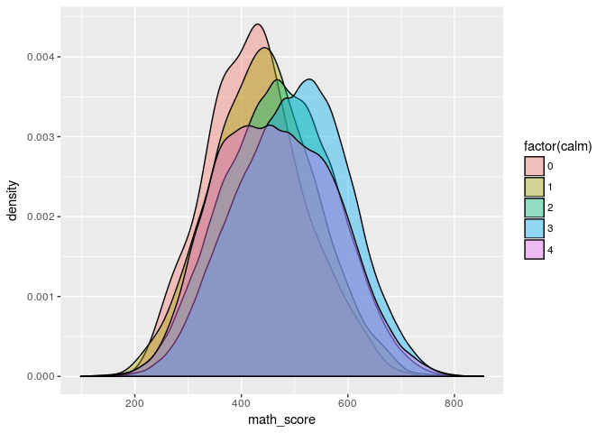

```r
  calmness %>%
ggplot(aes(x = math_score , fill = factor(calm))) + geom_density(alpha=0.4)
```

and check it by anova :

```r
calmness %>%
  aov(math_score ~ factor(calm) , data = .) -> fit
summary.aov(fit)
```

```
##                  Df    Sum Sq  Mean Sq F value Pr(>F)
## factor(calm)      4 5.074e+07 12684204    1178 <2e-16 ***
## Residuals    248729 2.679e+09    10771
## ---
## Signif. codes:  0 '***' 0.001 '**' 0.01 '*' 0.05 '.' 0.1 ' ' 1
```

so as p-valure is two low there is a significant diffrence on the mean of 5 group of calmness in the school .

۵. معلمان با تحصیلات بالاتر یا تجربه بیشتر دانش آموزان موفق تری تربیت می کنند.

۶. پسران در کاربرد هندسه قوی تر هستند.

i use tims data that is summery of tests to solve this question.

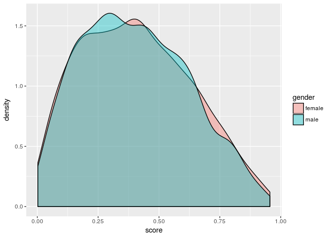

```r
tims = read_rds("Data/timss_2015.rds")
tims %>%
  filter(content_domain=='Geometry') %>%
  select(female = correct_ratio_per_question_female,
                male = correct_ratio_per_question_male) %>%
  tidyr::gather("female","male", key = "gender",value = "score") -> geo_gen
ggplot(geo_gen,aes(x=score,fill=gender)) + geom_density(alpha = 0.4)
```

we are not sure witch one is better . so i will use t test with alternative that male are better than female .

```r
t.test(score~gender ,data = geo_gen , alt="less")
```

```
##
##  Welch Two Sample t-test
##
## data:  score by gender
## t = 0.58939, df = 2919.5, p-value = 0.7222
## alternative hypothesis: true difference in means is less than 0
## 95 percent confidence interval:
##        -Inf 0.01822637
## sample estimates:
## mean in group female   mean in group male
##            0.4079455            0.4031385
```

۷. تغذیه دانش آموزان نقش اساسی در یادگیری آنها دارد.

i use question 12 from bsg data that ask about eating breakfast on school days :) i use one way anova for see any deffrence in deffrent in groups .

```r
bsg %>%
  select(idcntry,idschool,idstud, bsmmat01:bsmmat05 , bsbg12)%>%
  na.omit() %>%
  group_by(idcntry,idstud,idschool) %>%
  summarize(math_score = mean(c(bsmmat01:bsmmat05)),
            brk = bsbg12) -> eatt
```

ploting result :

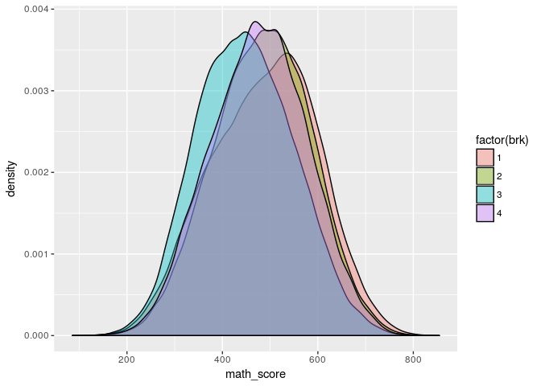

```r
eatt %>%
  ggplot(aes(x=math_score , fill =  factor(brk))) + geom_density(alpha = 0.4 )
```

as we know 1 is for every day and 4 means almost never wating breakfast. as they are too close in this plot i use t.test for each 2 group .

```r
t.test(filter(eatt,brk==1)$math_score,filter(eatt,brk==2)$math_score , alt = "greater")
```

```
##
##  Welch Two Sample t-test
##
## data:  filter(eatt, brk == 1)$math_score and filter(eatt, brk == 2)$math_score
## t = 7.0897, df = 87702, p-value = 6.771e-13
## alternative hypothesis: true difference in means is greater than 0
## 95 percent confidence interval:
##  3.030046      Inf
## sample estimates:
## mean of x mean of y
##  488.4766  484.5312
```

```r
t.test(filter(eatt,brk==2)$math_score,filter(eatt,brk==3)$math_score, alt = "greater")
```

```
##
##  Welch Two Sample t-test
##
## data:  filter(eatt, brk == 2)$math_score and filter(eatt, brk == 3)$math_score
## t = 57.221, df = 99807, p-value < 2.2e-16
## alternative hypothesis: true difference in means is greater than 0
## 95 percent confidence interval:
##  34.34071      Inf
## sample estimates:
## mean of x mean of y
##  484.5312  449.1741
```

```r
t.test(filter(eatt,brk==3)$math_score,filter(eatt,brk==4)$math_score , alt = "greater")
```

```
##
##  Welch Two Sample t-test
##
## data:  filter(eatt, brk == 3)$math_score and filter(eatt, brk == 4)$math_score
## t = -40.492, df = 71145, p-value = 1
## alternative hypothesis: true difference in means is greater than 0
## 95 percent confidence interval:
##  -28.46864       Inf
## sample estimates:
## mean of x mean of y
##  449.1741  476.5315
```

۸. مدارس با امکانات بیشتر دارای عملکرد بهتری می باشند.

۹. علت افت تحصیلی عدم مشارکت در کلاس است.

it can not be said that only not being on the school has effect bad on score but in here im going to see does it have any effect or not :) i use question 11 from student (bsg) to findout how it effect to be absent :

```r
bsg %>%
   mutate (math_score = (bsmmat01+ bsmmat02+ bsmmat03 +  bsmmat04 +  bsmmat05)/5)%>%
  select(idcntry,idstud, absent=bsbg11  , math_score) ->
  ab_score
```

as we know 1 means being absent a lot and 4 means being less absent .

```r
hcboxplot(x = ab_score$math_score, var = ab_score$absent,name="Length",color="blue") %>%
  hc_add_theme(hc_theme_chalk())
```

[interactive chart not shown]

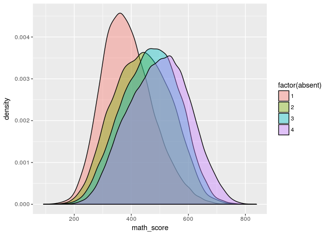

```r
ab_score %>%
  na.omit(.,cols = c('math_score', 'absent')) %>%
  ggplot(aes(x = math_score , fill = factor(absent))) + geom_density(alpha=0.4)
```

it seems that it realy effect :test it by one way anova .

```r
ab_score %>%
  aov(math_score ~ factor(absent) , data = .) -> fit
summary.aov(fit)
```

```
##                    Df    Sum Sq  Mean Sq F value Pr(>F)
## factor(absent)      3 2.687e+08 89568437    8687 <2e-16 ***
## Residuals      264981 2.732e+09    10311
## ---
## Signif. codes:  0 '***' 0.001 '**' 0.01 '*' 0.05 '.' 0.1 ' ' 1
## 15145 observations deleted due to missingness
```

so the hypothesis that being absent has no effect on score can rejected now. by this much little p value . ***

۱۰. دانش آموزان ایرانی در استدلال قوی تر از کاربرد هستند.

like what i do in question 6 for male and female :

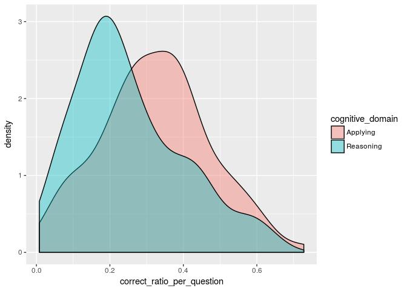

```r
tims %>%
  filter((Country == "Iran, Islamic Rep. of") & (cognitive_domain !="Knowing")) %>%
  ggplot(aes(x = correct_ratio_per_question , fill = cognitive_domain)) + geom_density(alpha = 0.4)
```

```r
t.test(tims[tims$cognitive_domain=="Reasoning",]$correct_ratio_per_question ,
       tims[tims$cognitive_domain=="Applying",]$correct_ratio_per_question , alt = "greater")
```

```
##
##  Welch Two Sample t-test
##
## data:  tims[tims$cognitive_domain == "Reasoning", ]$correct_ratio_per_question and tims[tims$cognitive_domain == "Applying", ]$correct_ratio_per_question
## t = -12.332, df = 3187.4, p-value = 1
## alternative hypothesis: true difference in means is greater than 0
## 95 percent confidence interval:
##  -0.09024479         Inf
## sample estimates:
## mean of x mean of y
## 0.3425676 0.4221889
```

سه گزاره جالب کشف کنید و ادعای خود را ثابت نمایید.

1- i have this hypothesis that when you expect yourself for upper education in future you will have better results now . question 8 ask about ezpectation of future degree by student .

```r
bsg %>%
  select(idcntry,idschool,idstud, bsmmat01:bsmmat05 , bsbg08)%>%
  na.omit() %>%
  group_by(idcntry,idstud,idschool) %>%
  summarize(math_score = mean(c(bsmmat01:bsmmat05)),
            expect = bsbg08) -> exp_score
```

ploting result :

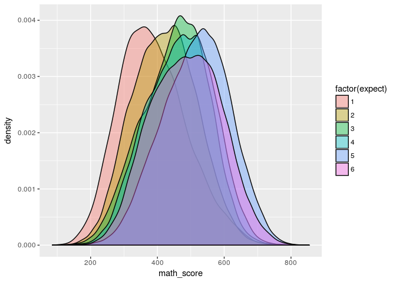

```r
exp_score %>%
  ggplot(aes(x=math_score , fill =  factor(expect))) + geom_density(alpha = 0.4 )
```

and test it by one way anova :

```r
exp_score %>%
  aov(math_score ~ factor(expect) , data = .) -> fit
summary.aov(fit)
```

```
##                    Df    Sum Sq  Mean Sq F value Pr(>F)
## factor(expect)      5 2.926e+08 58516191    5726 <2e-16 ***
## Residuals      271149 2.771e+09    10220
## ---
## Signif. codes:  0 '***' 0.001 '**' 0.01 '*' 0.05 '.' 0.1 ' ' 1
```

so expectation of your future have effect on your current score :)

2- i think that if stu use digital system in home a lot they will get less score : question 13a in bsg talk about this problem .

```r
bsg %>%
  select(idcntry,idschool,idstud, bsmmat01:bsmmat05 , bsbg13a)%>%
  na.omit() %>%
  group_by(idcntry,idstud,idschool) %>%
  summarize(math_score = mean(c(bsmmat01:bsmmat05)),
            net = bsbg13a) -> net_score
```

ploting result :

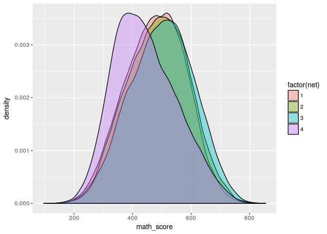

```r
net_score %>%
  ggplot(aes(x=math_score , fill =  factor(net))) + geom_density(alpha = 0.4 )
```

test it by one way anova :

```r
net_score %>%
  aov(math_score ~ factor(net) , data = .) -> fit
summary.aov(fit)
```

```
##                 Df    Sum Sq  Mean Sq F value Pr(>F)
## factor(net)      3 5.728e+07 19094321    1738 <2e-16 ***
## Residuals   271928 2.988e+09    10989
## ---
## Signif. codes:  0 '***' 0.001 '**' 0.01 '*' 0.05 '.' 0.1 ' ' 1
```

3- i think that more books you have in your shel in home you will be more sycceded in study . question 4 talk about this problem .

```r
bsg %>%
  select(idcntry,idschool,idstud, bsmmat01:bsmmat05 , bsbg04)%>%
  na.omit() %>%
  group_by(idcntry,idstud,idschool) %>%
  summarize(math_score = mean(c(bsmmat01:bsmmat05)),
            book = bsbg04) -> book_score
```

ploting result :

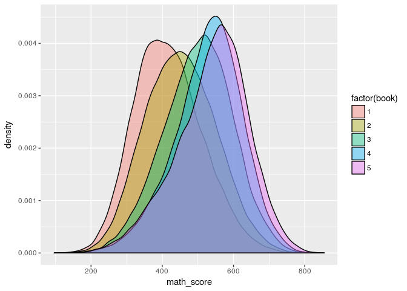

```r
book_score %>%
  ggplot(aes(x=math_score , fill =  factor(book))) + geom_density(alpha = 0.4 )
```

and by one way anova too it accepted .

```r
book_score %>%
  aov(math_score ~ factor(book) , data = .) -> fit
summary.aov(fit)
```

```
##                  Df    Sum Sq   Mean Sq F value Pr(>F)
## factor(book)      4 5.053e+08 126335550   13315 <2e-16 ***
## Residuals    275494 2.614e+09      9488
## ---
## Signif. codes:  0 '***' 0.001 '**' 0.01 '*' 0.05 '.' 0.1 ' ' 1
```